# **Exploring Titanic Survival Patterns: A Data Analysis Project**

WHAT IS THE BIGGEST FACTOR THAT IMPACTED SURVIVAL IN THE TITANIC?

## **Introduction**:

The sinking of the Titanic remains one of the most tragic maritime disasters in history, capturing the imagination and curiosity of people worldwide. This data analysis project delves into the passenger manifest of the Titanic, aiming to uncover patterns and insights that shed light on the factors influencing survival during that fateful voyage.

The Titanic dataset, sourced from the renowned Kaggle platform, provides a comprehensive snapshot of passenger information, including demographics, socio-economic status, and crucial details related to the journey. By leveraging the power of data analytics, this project seeks to answer pivotal questions and extract meaningful observations that contribute to our understanding of the dynamics at play during this iconic event.

Through a series of carefully crafted questions, we explore the impact of gender, age, passenger class, fares, and other variables on survival rates. Each question is a step towards unraveling the complex interplay of factors that determined who lived and who tragically perished.

This journey into the Titanic dataset involves not only statistical analysis but also the creation of actionable insights that can inform future discussions, emergency planning, or historical understanding. The findings aim to distill complex patterns into digestible narratives, making the project accessible to a wide audience interested in the human aspects of this historical event.

Whether you are a data enthusiast, a Titanic history buff, or someone curious about the stories hidden within datasets, this project invites you to explore, analyze, and reflect on the factors that shaped the fate of those aboard the ill-fated Titanic.

## **Raw Dataset**

titanic.csv

Link: https://www.kaggle.com/c/titanic/data?select=train.csv

## **Loading Data and Preprocessing**

### 1. Importing the dataset into DataFrame:

The very first task is to import the required libraries. In this case, we need Pandas, Seaborn, and Matplotlib, so you can see in the following coding snippet that we imported these libraries:

```python
import pandas as pd
import matplotlib.pyplot as plt
import seaborn as sns

# Load data into a Pandas DataFrame
titanic_df = pd.read_csv("titanic.csv")
```

Also, in line #6, we imported the dataset CSV into the Pandas DataFrame.

### 2. Exploring, selecting, cleaning, and preparing the data:

#### a. See the columns:

We can use the titanic_df.columns to get all columns from the dataframe.

```python
titanic_df.columns
```

```
Index(['PassengerId', 'Survived', 'Pclass', 'Name', 'Sex', 'Age', 'SibSp',
       'Parch', 'Ticket', 'Fare', 'Cabin', 'Embarked'],
      dtype='object')
```

#### b. Display the top 5 rows from the DataFrame data:

In the following coding snippet, we used titanic_df.head() to display the top five rows of the DataFrame data:

```python
titanic_df.head()
```

|  | PassengerId | Survived | Pclass | Name | Sex | Age | SibSp | Parch | Ticket | Fare | Cabin | Embarked |
| --- | --- | --- | --- | --- | --- | --- | --- | --- | --- | --- | --- | --- |
| 0 | 1 | 0 | 3 | Braund, Mr. Owen Harris | male | 22.0 | 1 | 0 | A/5 21171 | 7.2500 | NaN | S |
| 1 | 2 | 1 | 1 | Cumings, Mrs. John Bradley (Florence Briggs Th... | female | 38.0 | 1 | 0 | PC 17599 | 71.2833 | C85 | C |
| 2 | 3 | 1 | 3 | Heikkinen, Miss. Laina | female | 26.0 | 0 | 0 | STON/O2. 3101282 | 7.9250 | NaN | S |
| 3 | 4 | 1 | 1 | Futrelle, Mrs. Jacques Heath (Lily May Peel) | female | 35.0 | 1 | 0 | 113803 | 53.1000 | C123 | S |
| 4 | 5 | 0 | 3 | Allen, Mr. William Henry | male | 35.0 | 0 | 0 | 373450 | 8.0500 | NaN | S |

#### c. Display the last five rows from the data frame data:

In the following coding snippet, we used titanic_df.tail() to display the bottom five rows of the data frame data:

```python
titanic_df.tail()
```

|  | PassengerId | Survived | Pclass | Name | Sex | Age | SibSp | Parch | Ticket | Fare | Cabin | Embarked |
| --- | --- | --- | --- | --- | --- | --- | --- | --- | --- | --- | --- | --- |
| 886 | 887 | 0 | 2 | Montvila, Rev. Juozas | male | 27.0 | 0 | 0 | 211536 | 13.00 | NaN | S |
| 887 | 888 | 1 | 1 | Graham, Miss. Margaret Edith | female | 19.0 | 0 | 0 | 112053 | 30.00 | B42 | S |
| 888 | 889 | 0 | 3 | Johnston, Miss. Catherine Helen "Carrie" | female | NaN | 1 | 2 | W./C. 6607 | 23.45 | NaN | S |
| 889 | 890 | 1 | 1 | Behr, Mr. Karl Howell | male | 26.0 | 0 | 0 | 111369 | 30.00 | C148 | C |
| 890 | 891 | 0 | 3 | Dooley, Mr. Patrick | male | 32.0 | 0 | 0 | 370376 | 7.75 | NaN | Q |

#### d. Display the shape of the DataFrame (rows and columns):

```python
titanic_df.shape
```

```
(891, 12)
```

#### e. Check for null values to start data cleaning

We used the isnull() function to check the null values present in the data frame. In the following example, we can see that some columns have null values:

```python
titanic_df.isnull().sum()
```

```
PassengerId      0
Survived         0
Pclass           0
Name             0
Sex              0
Age            177
SibSp            0
Parch            0
Ticket           0
Fare             0
Cabin          687
Embarked         2
dtype: int64
```

#### f. Dropping the rows with null values

The following coding snippet contains the code to drop all null values, mostly in columns 'Age', 'Cabin', 'Embarked'.

```python
titanic_df.dropna(inplace = True)
titanic_df.isnull().sum()
```

```
PassengerId    0
Survived       0
Pclass         0
Name           0
Sex            0
Age            0
SibSp          0
Parch          0
Ticket         0
Fare           0
Cabin          0
Embarked       0
dtype: int64
```

We can see no null present after dropping all null values from the DataFrame.

#### g. Check for the duplicates:

In the following coding snippet, I have checked for duplicates and found that there is no duplicate data present:

```python
titanic_df.duplicated().sum()
```

```
0
```

#### h. Checking the datatypes of the columns:

In the following coding snippet, we printed the data types for all columns in the DataFrame:

```python
titanic_df.dtypes
```

```
PassengerId      int64
Survived         int64
Pclass           int64
Name            object
Sex             object
Age            float64
SibSp            int64
Parch            int64
Ticket          object
Fare           float64
Cabin           object
Embarked        object
dtype: object
```

#### i. Sorting the DataFrame:

In the following coding snippet, we sorted the data frame on the column Name:

```python
titanic_df.sort_values('Name')
```

|  | PassengerId | Survived | Pclass | Name | Sex | Age | SibSp | Parch | Ticket | Fare | Cabin | Embarked |
| --- | --- | --- | --- | --- | --- | --- | --- | --- | --- | --- | --- | --- |
| 730 | 731 | 1 | 1 | Allen, Miss. Elisabeth Walton | female | 29.00 | 0 | 0 | 24160 | 211.3375 | B5 | S |
| 305 | 306 | 1 | 1 | Allison, Master. Hudson Trevor | male | 0.92 | 1 | 2 | 113781 | 151.5500 | C22 C26 | S |
| 297 | 298 | 0 | 1 | Allison, Miss. Helen Loraine | female | 2.00 | 1 | 2 | 113781 | 151.5500 | C22 C26 | S |
| 498 | 499 | 0 | 1 | Allison, Mrs. Hudson J C (Bessie Waldo Daniels) | female | 25.00 | 1 | 2 | 113781 | 151.5500 | C22 C26 | S |
| 460 | 461 | 1 | 1 | Anderson, Mr. Harry | male | 48.00 | 0 | 0 | 19952 | 26.5500 | E12 | S |
| ... | ... | ... | ... | ... | ... | ... | ... | ... | ... | ... | ... | ... |
| 124 | 125 | 0 | 1 | White, Mr. Percival Wayland | male | 54.00 | 0 | 1 | 35281 | 77.2875 | D26 | S |
| 102 | 103 | 0 | 1 | White, Mr. Richard Frasar | male | 21.00 | 0 | 1 | 35281 | 77.2875 | D26 | S |
| 318 | 319 | 1 | 1 | Wick, Miss. Mary Natalie | female | 31.00 | 0 | 2 | 36928 | 164.8667 | C7 | S |
| 377 | 378 | 0 | 1 | Widener, Mr. Harry Elkins | male | 27.00 | 0 | 2 | 113503 | 211.5000 | C82 | C |
| 325 | 326 | 1 | 1 | Young, Miss. Marie Grice | female | 36.00 | 0 | 0 | PC 17760 | 135.6333 | C32 | C |

183 rows × 12 columns

## **Questions to Answer**

1. How does survival vary by gender?
2. What is the distribution of survival rates among different age groups (e.g., children, adults, elderly)?
3. What is the distribution of passenger classes among survivors and non survivors?
4. What is the distribution of fares paid by passengers?
5. Did fares play a role in their survival?
6. What is the average age of passengers?
7. What is the overall survival rate?
8. How many passengers embarked from each port (C = Cherbourg, Q = Queenstown, S = Southampton)?
9. Did the port of embarkation impact survival rates?
10. What was the distribution of cabin classes?
11. How did the survival rates vary among different cabin classes and decks?
12. Can we identify any patterns or trends in the names or titles of passengers that might be correlated with survival?
13. Find the number of people in each cabin on the Titanic.

### How does survival vary by gender?

The following code calculates the survival rate based on gender. It first groups the titanic dataset by the 'Sex' column then calculates the mean of the 'Survived' column for each group.

```python
# Gender-wise Survival Rate
gender_survival_rate = titanic_df.groupby('Sex')['Survived'].mean()
print("Survival Rate by Gender:")
print(gender_survival_rate)
```

```
Survival Rate by Gender:
Sex
female    0.931818
male      0.431579
Name: Survived, dtype: float64
```

The output shows the survival rate for males and females. The survival rate for females is 0.931818. The survival rate for males is 0.431579.

**Insight:** Females had a significantly higher survival rate (93.2%) compared to males (43.2%). This is probably because of prioritizing women and children in emergency situations.

### What is the distribution of survival rates among different age groups (e.g., children, adults, elderly)?

The following code calculates the survival rate by age group. It first creates categorical age groups based on the 'Age' column and it bins them in specific groups. Then it groups the dataset by the predefined age groups and calculates the mean of the 'Survived' column for each group.

```python
# Age-wise Survival Rate
age_survival_rate = pd.cut(titanic_df['Age'], bins=[0, 18, 35, 60, 100], labels=['Child', 'Adult', 'Middle-aged', 'Elderly'])
age_survival_rate = titanic_df.groupby(age_survival_rate)['Survived'].mean()
print("Survival Rate by Age Group:")
print(age_survival_rate)
```

```
Survival Rate by Age Group:
Age
Child          0.869565
Adult          0.761194
Middle-aged    0.602410
Elderly        0.200000
Name: Survived, dtype: float64
```

The output shows the survival rate for Children, Adults, Middle-aged people, and Elderly.

**Insight:** Children (0-18) had the highest survival rate (86.9%), followed by adults (76.1%), middle-aged (60.2%), and the elderly (20%). In emergency plans, specific accommodations and attention are provided for vulnerable age groups.

### What is the distribution of passenger classes among survivors and non survivors?

The following code calculates the distribution of passenger classes among survivors and nonsurvivors. It first groups the dataset by the 'Survived' and 'Pclass' columns and calculates the occurnces of each group. Then it rearranges the grouped data to compare the distribution of passenger classes between survivors and non-survivors.

```python
# Pclass-wise Distribution among Survivors and Non-survivors
pclass_distribution = titanic_df.groupby(['Survived', 'Pclass']).size().unstack()
print("Distribution of Passenger Classes among Survivors and Non-survivors:")
print(pclass_distribution)
```

```
Distribution of Passenger Classes among Survivors and Non-survivors:
Pclass      1   2  3
Survived
0          52   3  5
1         106  12  5
```

The output shows that there were 52 non survivors from the 1st class, 3 from 2nd class, and 5 from 3rd class. 106 survivors from the 1st class, 12 from 2nd class, and 5 from 3rd class.

**Insight:** Passengers in higher classes (1st and 2nd) had higher survival rates compared to 3rd class.

### What is the distribution of fares paid by passengers?

The following code uses the seaborn library to create a histogram. It visualizes the distribution of fares among passengers.

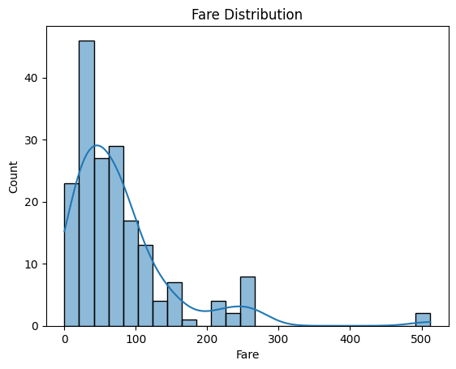

```python
# Fare Distribution
sns.histplot(titanic_df['Fare'], kde=True)
plt.title('Fare Distribution')
plt.show()
```

The output shows a histogram showing the distribution of fares on the dataset. This offers insights into the economic diversity among passengers. Which will assist in understanding the following code:

### Did fares play a role in their survival?

The following code creates a boxplot to visualize the relationship between 'Fare' and 'Survived' columns using the seaborn library.

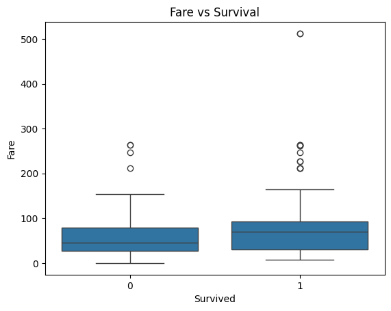

```python
# Fare vs Survival
sns.boxplot(x='Survived', y='Fare', data=titanic_df)
plt.title('Fare vs Survival')
plt.show()
```

The output shows a comparison of the fare distribution of passengers who did not survive and those who survived. This helps understand whether fare paid might be associated with survival rate on the Titanic. The box area on the right indicates that there are many datapoints there. As it is seen the right box area is slightly higher than the left box area which ultimately means fares did play a small role in survival.

**Insight:** The distribution of fares varied, and there's a visible trend that higher fares might be associated with higher survival. This shows that fare information can be used as an additional factor in emergency response planning.

### What is the average age of passengers?

The following code calculates the average age of passengers in the dataset. It first calculates the mean of the 'Age' column. Then sums all ages and divides them by the total number of passengers with the available age information.

```python
# Average Age
average_age = titanic_df['Age'].mean()
print("Average Age of Passengers:", average_age)
```

```
Average Age of Passengers: 35.6744262295082
```

The output shows that on average the passengers in the Titanic were aged around 35 years old.

**Insight:** The average age of passengers was 35.67. The age distribution affects planning for the needs of different age groups

### What is the overall survival rate?

The following code calculates the overall survival rate of passengers on the Titanic. It first calculates the 'mean' of the Survived column.

```python
# Overall Survival Rate
overall_survival_rate = titanic_df['Survived'].mean()
print("Overall Survival Rate:", overall_survival_rate)
```

```
Overall Survival Rate: 0.6721311475409836
```

The ouput shows that the overall survival rate is 0.67 which is approximately 67%.

**Insight:** The overall survival rate was 67.2%.

### How many passengers embarked from each port (C = Cherbourg, Q = Queenstown, S = Southampton)?

The following code explains the distribution of passengers embarked from each port.

```python
# Passengers embarked from each port
embarkation_counts = titanic_df['Embarked'].value_counts()
print("Passengers Embarked from Each Port:")
print(embarkation_counts)
```

```
Passengers Embarked from Each Port:
Embarked
S    116
C     65
Q      2
Name: count, dtype: int64
```

The following output calculates the number of passengers who embarked from each port. It groups the ports by the following letters: ('S','C','Q') the results are ('116', '65', '2') respectively.

### Did the port of embarkation impact survival rates?

The following code focuses on the survival rate of the passengers based on the embarkation ports. It uses 'groupby' function to group the data by embarkation point then calculates the average survival for each embarkation point.

```python
# Embarkation-wise Survival Rate
embarkation_survival_rate = titanic_df.groupby('Embarked')['Survived'].mean()
print("\nSurvival Rate by Embarkation Port:")
print(embarkation_survival_rate)
```

```
Survival Rate by Embarkation Port:
Embarked
C    0.738462
Q    0.500000
S    0.637931
Name: Survived, dtype: float64
```

The output shows the survival rate of each embarkation port. 73% for port C, 50% for port Q, around 64% for port S.

**Insight:** Passengers who embarked from Cherbourg had the highest survival rate (73.8%), followed by Southampton (63.8%) and Queenstown (50%).

### What was the distribution of cabin classes?

The following code focuses on the distribution of cabin classes. It the first letter from the 'Cabin' column to create a new column 'CabinClass'. Then it counts the occurences of each cabin class and visualizes the distribution using a bar plot.

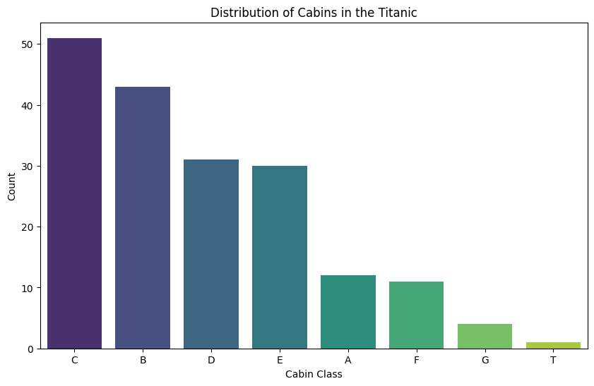

```python
# Extract the first letter of the Cabin column to create a CabinClass column
titanic_df['CabinClass'] = titanic_df['Cabin'].str[0]

# Count the number of occurrences of each cabin class
cabin_distribution = titanic_df['CabinClass'].value_counts()

# Plot the distribution of cabins
plt.figure(figsize=(10, 6))
sns.barplot(x=cabin_distribution.index, y=cabin_distribution.values, palette="viridis")
plt.title('Distribution of Cabins in the Titanic')
plt.xlabel('Cabin Class')
plt.ylabel('Count')
plt.show()
```

The output shows the distribution of cabin classes among the Titanic with the count of cabins in each cabin class.

### How did the survival rates vary among different cabin classes and decks?

The following code focuses on the survival rate of passengers based on their cabin classes. It groups the data by cabin class and calculates the mean survival rate for each group.

```python
# Cabin Class-wise Survival Rate
cabin_class_survival_rate = titanic_df.groupby('CabinClass')['Survived'].mean()
print(cabin_class_survival_rate)
```

```
CabinClass
A    0.583333
B    0.744186
C    0.588235
D    0.741935
E    0.733333
F    0.636364
G    0.500000
T    0.000000
Name: Survived, dtype: float64
```

The output shows that cabin B had the highest survival rate at 74.4%. and cabin T had the lowest survival rate at 0%.

### Can we identify any patterns or trends in the names or titles of passengers that might be correlated with survival?

The following code extracts titles from passenger names and looks into the survival rate based on these titles. It extracts titles from the 'Name' column and then calculates the average survival for each title category.

```python
# Extracting titles from names
titanic_df['Title'] = titanic_df['Name'].str.extract(' ([A-Za-z]+)\.')

# Title-wise Survival Rate
title_survival_rate = titanic_df.groupby('Title')['Survived'].mean()
print("Survival Rate by Title (in percentage):")
print(title_survival_rate)
```

```
Survival Rate by Title (in percentage):
Title
Capt        0.000000
Col         1.000000
Countess    1.000000
Dr          0.666667
Lady        1.000000
Major       0.500000
Master      1.000000
Miss        0.931818
Mlle        1.000000
Mme         1.000000
Mr          0.370370
Mrs         0.921053
Sir         1.000000
Name: Survived, dtype: float64
```

**Insight:** Passengers with titles like "Miss," "Mrs," and "Mlle" had high survival rates, while titles like "Mr" had a lower rate. In this emergency situation, individuals with titles are associated with higher survival rates.

### Find the number of people in each cabin in the Titanic

The following code creates a dictionary where keys represent the count of occurences of each cabin and values are lists of cabins with that count.

```python
# Count the number of occurrences of each unique cabin
cabin_distribution = titanic_df['Cabin'].value_counts()

# Create a dictionary to store cabins grouped by count
count_cabins_dict = {}
for cabin, count in cabin_distribution.items():
    if count not in count_cabins_dict:
        count_cabins_dict[count] = [cabin]
    else:
        count_cabins_dict[count].append(cabin)

# Print counts along with cabins having that count, starting from count 1
for count in range(1, max(count_cabins_dict.keys()) + 1):
    if count in count_cabins_dict:
        cabins_str = ', '.join(count_cabins_dict[count])
        print(f"{count} - {cabins_str}")
```

```
1 - B50, A26, C85, A23, D9, D50, E58, D19, A20, B41, E68, A10, C101, A16, C70, C86, D48, C126, B71, D49, B42, C50, A24, E17, D28, E49, B69, A36, B82 B84, D6, B3, E77, D11, D30, C46, B101, C45, B38, C90, C62 C64, F G63, B39, C52, B73, B19, C118, C99, B94, C87, D15, A31, B80, B4, C49, A7, B86, D46, D4…
2 - B35, C65, F4, E44, C123, D36, E121, C93, C78, D35, E8, B77, E67, C125, C2, B57 B59 B63 B66, E24, F G73, B22, E25, B51 B53 B55, D20, D33, B18, C83, B49, B5, C68, D26, D17, B58 B60, E101, B20
3 - F33, D, C22 C26, F2
4 - G6, B96 B98, C23 C25 C27
```

The output shows a dictonary with the number of people in the cabin as the key and number of cabins as values. It shows the cabins that had one person in them, 2 people, 3 people, and 4 people.

**Insight:** Cabins with counts of 1 to 4 are diverse, and some cabins are shared by multiple passengers. The cabin distribution helps to understand the spatial arrangement and potential impact on evacuation.

## **Conclusion**:

In emergency preparedness, understanding these factors is crucial. Allocation of resources, prioritization in evacuation plans, and tailored approaches for different groups can enhance the chances of survival. The insights derived from the analysis provide a nuanced understanding of the Titanic's passengers, aiding in creating more effective and inclusive emergency response strategies.

## **My Personal Thoughts and Insights**:

For this project, there were 5 of us in a team. I worked with Hiba Al-Nabhani, David Jotkus, Siddhardh Tekumalla, and Julio Born. We started off by choosing a dataset from Kaggle. We all agreed on using the Titanic dataset because it's interesting, and even though it's very common, we wanted to explore and analyze it ourselves.

We got together over Zoom to discuss the outline of our project and form a list of questions. We created a Teams chat for easy communication, created a shared Jupyter notebook that we all could edit, created a Google Doc to list down all important points, and we even tried collaborating on the same repository. However, we scrapped the last idea since all submissions had to be individual anyways.

Overall, it took us two days to complete this project. We used the Case Example provided to us by our professor, Prof. Mathias Fonkam, to format our notebook. I was in-charge of formatting, putting everything together, and making our work presentable.

I commend all my teammates as they all did their part efficiently and really well.